# ¶ **Proyecto de Estadística y Probabilidades I (4ta Entrega)**

16 de Diciembre del 2021

# 1 Correcciones

- En base a las entregas anteriores, los cambios que hemos venido realizando son: la selección de variables suficientes para el estudio, aplicaciones de regresión entre variables numéricas continuas, así como también, mejoramos la interpretación de las gráficas.

# 2 Tema

- Estudio sobre situación de anemia de los niños menores de 5 años del departamento de Cusco.

# 3 Relevancia

## 3.1 Importancia y justificación

- En el Perú es importante determinar la situación de anemia en Cusco como la concentración de pacientes afectados por la anemia para centrar la atención en zonas focalizadas y proponer alternativas de solución que gestionen la repartición de recursos o medicamentos que posiblemente carezcan las redes de Salud con el objetivo de combatir la anemia.
- La base de datos se registró de acuerdo a las Historias Clínicas de los Establecimientos de Salud del Ministerio de Perú, por lo que se hace legítima la información.

# 4 Objetivos

## 4.1 Objetivo general

- Evaluar el perfil de las personas que están más propensas a sufrir anemia en las distintas provincias de Cusco.

## 4.2 Objetivos específicos

- Describir el comportamiento de las variables recolectadas (peso, talla, edad, hemoglobina, entre otros) respecto a la anemia.
- Determinar a lo largo del tiempo en qué regiones y en qué distritos ha habido una mayor prevalencia de personas con anemia en los trimestres de 2019 y 2020.

# 5 Factibilidad

- La organización para abordar cada entrega en los tiempos requeridos se hizo por medio de un diagrama de Gantt.

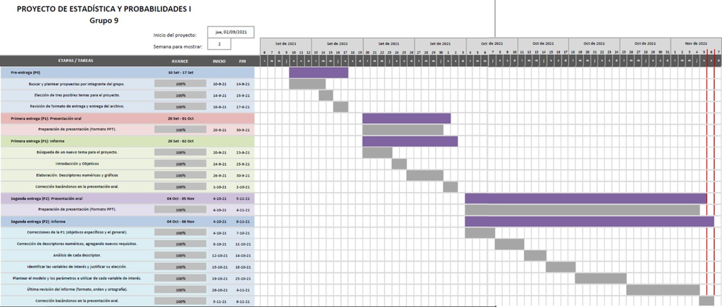

# 6 Marco teórico

## 6.1 Audiencia

- Beneficiaría como aporte al plan multi-sectorial de Lucha Contra la Anemia del Ministerio de Desarrollo e Inclusión Social (MIDIS). Uno de los componentes estratégicos del plan es la gestión territorial que se encuentra a cargo de cada gobierno local. Este se encarga de analizar la situación de los servicios que reciben los niños y niñas en su distrito con el objetivo de mejorar la cobertura y de expandir estos servicios(seguridad alimentaria, salud, educación, otros) a más niños y niñas. El conocimiento del alcalde sobre la situación de sus habitantes contribuye a una gestión de calidad, por ende la información que generemos sobre la concentración de pacientes de anemia menores de 5 años, permitirá una mejor visualización del problema y promoverá el enfoque en las zonas focalizadas para mayor atención.

## 6.2 Objeto de estudio

- Niños y niñas menores de 5 años a menos.

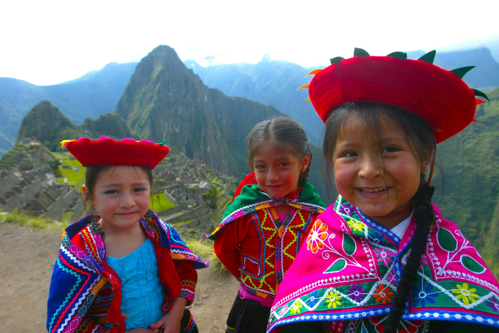

## 6.3 Sesgo

La base de datos fue recolectada por cada red de salud del MINSA y algunos datos eran registros de niños de otro origen departamental que se hicieron revisar en las redes de Cusco, por lo que se filtró esa data.

## 6.4 Limpieza del data frame

La condición establecida para la selección de variables de la base de datos es la relevancia de las variables para el estudio en base a los objetivos.

Se utilizó el R Notebook llamado **Limpieza.Rmd** para limpiar el Data Frame y producir el nuevo data limpia “cusco”.

# 7 Variables de estudio

[output not shown]

# 8 Descriptores Gráficos

## 8.3 Casos atendidos por Red de Salud

- El 24.98% de niños y niñas se atendieron en CUSCO NORTE.
- El 31.17% de niños y niñas se atendieron en CUSCO SUR.
- El 8.71% de niños y niñas se atendieron en CHUMBIVILCAS.
- El 23.73% de niños y niñas se atendieron en CANAS CANCHIS ESPINAR.
- El 7.19% de niños y niñas se atendieron en KIMBIRI PICHARI.
- El 4.22% de niños y niñas se atendieron en LA CONVENCIÓN.

## 8.4 Relación entre las variales ESTADO DE ANEMIA y SEXO(meses)

- Se registraron 9738 pacientes femeninas y 10194 pacientes masculinos.

Respecto al total de niños y niñas:

- Existe una mayoría de casos de niños con anemia LEVE que de niñas.
- Existe una mayoría de casos de niños con anemia MODERADA que de niñas.
- Existe una mayoría de casos de niños con anemia SEVERA que de niñas.
- El total de casos que presentan anemia severa son 260, de las cuales 108 son niñas y 152 son niños.

## 8.5 Hemoglobina(g/dL) vs. Edades (meses)

# 9 Análisis descriptivo de las variables continuas

# 10 Prueba de hipótesis e intervalos de confianza

Determinaremos los intervalos de confianza para una proporción poblacional con estimación por intervalos utilizando variables numéricas continuas.

- **Nivel de confianza:** $95 \%$
- **Nivel de significancia:** $\alpha=0.05$
- **Tamaño de la muestra:** $19932$

El intervalo de confianza utilizado es 0.95 tomando en cuenta la sugerencia por la comunidad científica, ya que es más frecuentemente usado cuando el tamaño de la muestra es lo suficientemente grande.

## 10.1 HIPÓTESIS 1:

Variable: Hemoglobina (g/ dL)

**H1** : La hemoglobina promedio de los niños entre los 0 y 5 de la ciudad de Cuzco es *menor* a 13.

**H1** : µ < 13 g/dL

**H0** : La hemoglobina promedio de los niños entre los 0 y 5 de la ciudad de Cuzco es *mayor o igual* a 13 .

**H0** : µ ≥ 13 g/dL

Interpretación:

Presentamos una hipótesis de cola izquierda:

- Zona de rechazo ≤ -1.644854
- Estadístico de prueba → 4.594648

Conclusión:

En base a la evidencia muestral no se puede rechazar H0.

## 10.2 INTERVALO DE CONFIANZA 1: Anemia Severa ( < 7) g/dL

El parámetro de proporción muestral ( 0.013 ) se encuentran en un 95% de los intervalos de confianza.

Resultado:

- Anemia Severa ( < 7) → [ 0.011 , 0.015 ]

## 10.3 INTERVALO DE CONFIANZA 2: Anemia Moderada (7, 9.9) g/dL

El parámetro de proporción muestral ( 0.217 ) se encuentran en un 95% de los intervalos de confianza.

Resultado:

- Anemia Moderada (7, 9.9) → [ 0.210 , 0.224 ]

## 10.4 INTERVALO DE CONFIANZA 3: Anemia Leve (10.0, 11.9) g/dL

El parámetro de proporción muestral ( 0.21 ) se encuentran en un 95% de los intervalos de confianza.

Resultado:

- Anemia Leve (10.0, 11.9) → [ 0.204 ; 0.216 ]

## 10.5 HIPÓTESIS 2:

Variable: Hemoglobina (g/ dL), masculino y femenino

**µm** → Hemoglobina promedio en niños de sexo masculino.

**µf** → Hemoglobina promedio en niños de sexo femenino.

**H1** : La hemoglobina promedio de los niños de sexo femenino es *mayor* a la hemoglobina promedio de los niños de sexo masculino.

**H1** : µf > µm

**H0** : La hemoglobina promedio de los niños de sexo femenino es *menor o igual* a la hemoglobina promedio de los niños de sexo masculino.

**H0** : µf ≤ µm

Interpretación:

Conclusión:

En base a la evidencia muestral no se puede rechazar H0.

## 10.6 INTERVALO DE CONFIANZA 4: Hemoglobina (g/ dL) por sexo, masculino y femenino

Los parámetros de proporción muestral ( 0.489 y 0.511 ) respectivamente se encuentran en un 95% de los intervalos de confianza.

Resultado:

- Niñas → [ 0.481 ; 0.496 ]
- Niños → [ 0.504 ; 0.519 ]

## 10.7 HIPÓTESIS 3:

Variabe: IMC (kg/m^2), niños con y sin anemia

**µc** → La media de IMC en los niños y niñas afectados por anemia.

**µs** → La media de IMC en los niños y niñas sin anemia.

**H1** : La media de IMC en los niños y niñas afectados por anemia es *menor* a la media de IMC en los niños y niñas sin anemia.

**H1** : µc < µs

**H0** : La media de IMC en los niños y niñas afectados por anemia es *mayor o igual* a la media de IMC en los niños y niñas sin anemia.

**H0** : µc ≥ µs

Interpretación:

Presentamos una hipótesis de cola izquierda:

- Zona de rechazo ≤ -1.644854
- Estadístico de prueba → -5.404585

## 10.8 INTERVALO DE CONFIANZA 5: IMC por casos con y sin anemia

Los parámetros de proporción muestral ( 0.439 y 0.561 ) respectivamente se encuentran en un 95% de los intervalos de confianza.

Resultado:

- Con anemia → [ 0.432 , 0.447 ]
- Sin anemia → [ 0.553 , 0.568 ]

## 10.9 INTERVALO DE CONFIANZA 6: Casos de anemia por intervalo de edad

Los parámetros de proporción muestral ( 0.276 , 0.366 , 0.178 , 0.112 , 0.068) se encuentran en un 95% de los intervalos de confianza.

Intervalos de confianza de cada edad:

- [ 0.266 , 0.286 ] ← 0 - 12 meses
- [ 0.355 , 0.377 ] ← 12 - 24 meses
- [ 0.169 , 0.186 ] ← 24 - 36 meses
- [ 0.105 , 0.119 ] ← 36 - 48 meses
- [ 0.062 , 0.074 ] ← 48 - 60 meses

# 11 Regresiones

## 11.1 CASO 1:

Variables: meses y casos de anemia

Tomando en cuenta los valores tomados de la prevalencia de anemia a tiempo mensual desde 2019 a 2020 identificamos el tipo de relación entres estas dos variables asemeja a una regresión lineal.

Para confirmar que sea un regresión lineal con ambas variables, primero se debe confirmar que $cor = +/-[0.6, 1]$ para observar si tiene un coeficiente de correlación fuerte.

El coeficiente de correlación es $-0.87$, por lo que se puede afirmar que existe una relación lineal negativa muy fuerte.

Se estima que la función de regresión está dada por : $P(t) = -2.1870t + 76.6599$, donde P(t) es la prevalencia en un instante de tiempo (mes). Sin embargo, se debe tomar en cuenta que los puntos presentados son pocos como para estimar un buena precisión de la pendiente, por lo que se recomienda trabajar con un intervalo de tiempo mayor al estudio realizado.

## 11.2 CASO 2:

Variables: Casos de anemia y edad

Tomando en cuenta los valores tomados de la prevalencia de anemia a tiempo mensual desde 2019 a 2020 identificamos el tipo de relación entres estas dos variables asemeja a una regresión lineal.

Para confirmar que sea un regresión lineal con ambas variables, primero se debe confirmar que $cor = +/-[0.6, 1]$ para observar si tiene un coeficiente de correlación fuerte.

El coeficiente de correlación es $-0.42$, por lo que no se puede afirmar que existe una relación lineal negativa muy fuerte.

# 12 Reflexiones y conclusiones

**1. ¿En qué red de Cusco hay una mayor cantidad de niños y niñas registrados con anemia?**

```
De acuerdo con nuestra base de datos, entre los años 2019 y 2020
hubo una mayor cantidad de casos registrados con anemia en la red
Cusco Sur.
```

**2. ¿Cuál es la provincia en donde hay más casos?**

```
La mayoría de los niños son de la provincia de Cusco, por lo que se
estima que es el motivo por el cual es la provincia donde hay más
casos de anemia.
```

**3. De acuerdo con el sexo de los niños, ¿quiénes han sido los más afectados por anemia?**

```
Se han registrado más casos de niños con anemia a comparación de las
niñas.

Niñas con anemia: 2004 + 1960 + 108 = 4072

Niños con anemia: 2178 + 2357 + 152 = 4687
```

**4. ¿Existe relación entre la edad y la anemia en los niños menores de 5 años?**

```
La correlación obtenida al realizar la regresión de ambas variables
fue - 0.42, esto significa que no existe una correlación lineal
fuerte. No podemos afirmar que exista alguna relación entre ambas
variables.
```